# Multiple linear regression

5. Let’s see if the apparent trend in the plot is something more than natural variation. Fit a linear model called `m_bty` to predict average professor score by average beauty rating and add the line to your plot using `abline(m_bty)`. Write out the equation for the linear model and interpret the slope. Is average beauty score a statistically significant predictor? Does it appear to be a practically significant predictor?

[figure not shown]

```r
m_bty = lm(evals$score~evals$bty_avg)
plot(evals$score~evals$bty_avg, xlab="Score", ylab="Beauty Avg", main="Score vs Beauty Avg")
abline(coefficients(m_bty), lty=2, col="blue")
```

```r
summary(m_bty)
```

```
##
## Call:
## lm(formula = evals$score ~ evals$bty_avg)
##
## Residuals:
##     Min      1Q  Median      3Q     Max
## -1.9246 -0.3690  0.1420  0.3977  0.9309
##
## Coefficients:
##               Estimate Std. Error t value Pr(>|t|)
## (Intercept)    3.88034    0.07614   50.96  < 2e-16 ***
## evals$bty_avg  0.06664    0.01629    4.09 5.08e-05 ***
## ---
## Signif. codes:  0 '***' 0.001 '**' 0.01 '*' 0.05 '.' 0.1 ' ' 1
##
## Residual standard error: 0.5348 on 461 degrees of freedom
## Multiple R-squared:  0.03502,    Adjusted R-squared:  0.03293
## F-statistic: 16.73 on 1 and 461 DF,  p-value: 5.083e-05
```

**Answer: From the summary of the fitted model we can see that coefficient of beauty average is positive (0.06664) and p value is close to 0 making it statistically significant. We can conclude that beauty average impacts the teachers score positively and each one unit increase in beauty average increases overal teacher rating by 0.06. The equation of the linear model can be written as score = 3.88 + 0.06664 * Avg Beauty**

**Even though avg beauty is a statistically significant predictor for practical purposes it just improves the teacher score by 0.06 for each one point increase in avg beauty level. This is not a lot and for practical purpose we can ignore this impact**

6. Use residual plots to evaluate whether the conditions of least squares regression are reasonable. Provide plots and comments for each one (see the Simple Regression Lab for a reminder of how to make these).

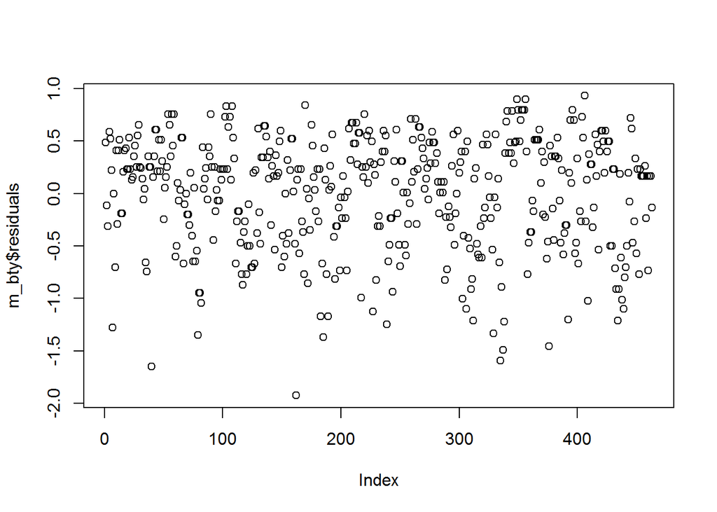

```r
plot(m_bty$residuals)
```